# 市场观察

2016/07/26

## 一、指数估值

### (一)指数动态市盈率

核心指数成分股的动态市盈率中位数走势如下图所示：

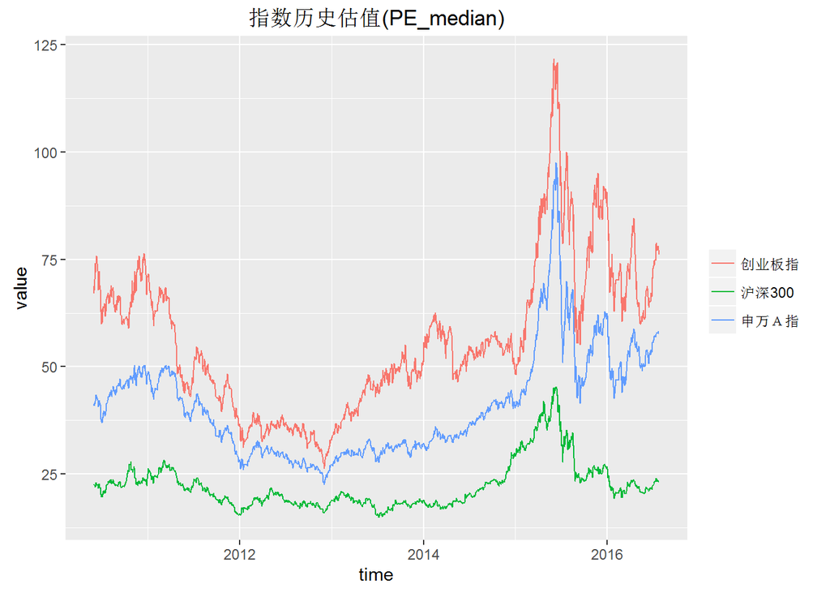

### (二)指数动态市盈率百分位

核心指数上述数据的百分位走势如下图所示：

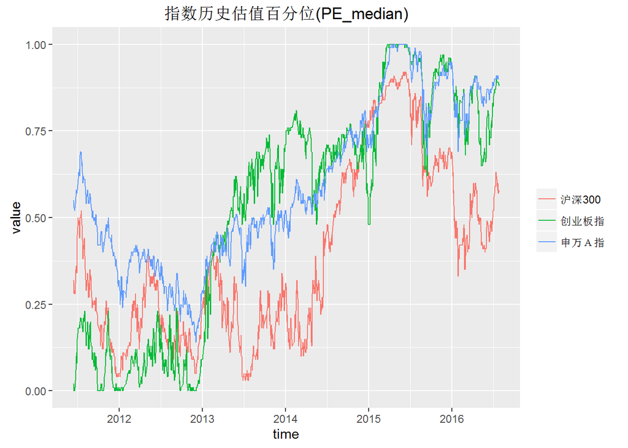

### (三)指数估值概览

纳入观察的18只指数最新的估值情况如下表：

| 日期 | 指数代码 | 指数简称 | 动态市盈率 | 上周动态市盈率 | 市盈率百分位 | 上周市盈率百分位 | 动态市净率 | 市净率百分位 |
| --- | --- | --- | --- | --- | --- | --- | --- | --- |
| 2016-07-25 | EI000979 | 大宗商品 | 48.96 | 50.24 | 0.96 | 0.97 | 2.56 | 0.48 |
| 2016-07-25 | EI000819 | 有色金属 | 64.94 | 67.88 | 0.91 | 0.95 | 4.43 | 0.89 |
| 2016-07-25 | EI801003 | 申万Ａ指 | 57.66 | 57.77 | 0.90 | 0.90 | 4.91 | 0.78 |
| 2016-07-25 | EI399006 | 创业板指 | 76.12 | 77.65 | 0.88 | 0.89 | 8.58 | 0.84 |
| 2016-07-25 | EI399005 | 中小板指P | 49.35 | 49.22 | 0.86 | 0.86 | 6.00 | 0.82 |
| 2016-07-25 | EI399959 | 军工指数 | 100.20 | 100.49 | 0.85 | 0.86 | 6.67 | 0.82 |
| 2016-07-25 | EI000998 | 中证TMT | 64.74 | 64.61 | 0.84 | 0.84 | 6.44 | 0.82 |
| 2016-07-25 | EI000805 | A股资源 | 48.17 | 51.03 | 0.83 | 0.88 | 2.53 | 0.58 |
| 2016-07-25 | EI399330 | 深证100 | 36.30 | 35.90 | 0.81 | 0.80 | 4.58 | 0.77 |
| 2016-07-25 | EI000808 | 医药生物 | 41.69 | 41.34 | 0.73 | 0.71 | 5.50 | 0.66 |
| 2016-07-25 | EI000933 | 中证医药 | 40.63 | 40.98 | 0.73 | 0.75 | 4.88 | 0.54 |
| 2016-07-25 | EI801120 | 申万食品饮料 | 45.64 | 46.52 | 0.72 | 0.73 | 4.57 | 0.60 |
| 2016-07-25 | EI000905 | 中证500 | 40.75 | 41.00 | 0.66 | 0.67 | 3.75 | 0.63 |
| 2016-07-25 | EI000300 | 沪深300 | 23.17 | 23.32 | 0.58 | 0.59 | 2.57 | 0.47 |
| 2016-07-25 | EI000827 | 中证环保 | 39.13 | 39.36 | 0.53 | 0.54 | 4.23 | 0.80 |
| 2016-07-25 | EI000932 | 中证消费 | 33.30 | 34.42 | 0.52 | 0.55 | 4.36 | 0.49 |
| 2016-07-25 | EI000934 | 中证金融 | 15.62 | 15.75 | 0.35 | 0.37 | 2.25 | 0.48 |
| 2016-07-25 | EI000016 | 上证50 | 12.02 | 12.07 | 0.09 | 0.09 | 1.52 | 0.06 |

## 二、基差

### (一)基差走势

三大股指期货隔季合约基差走势如下图：

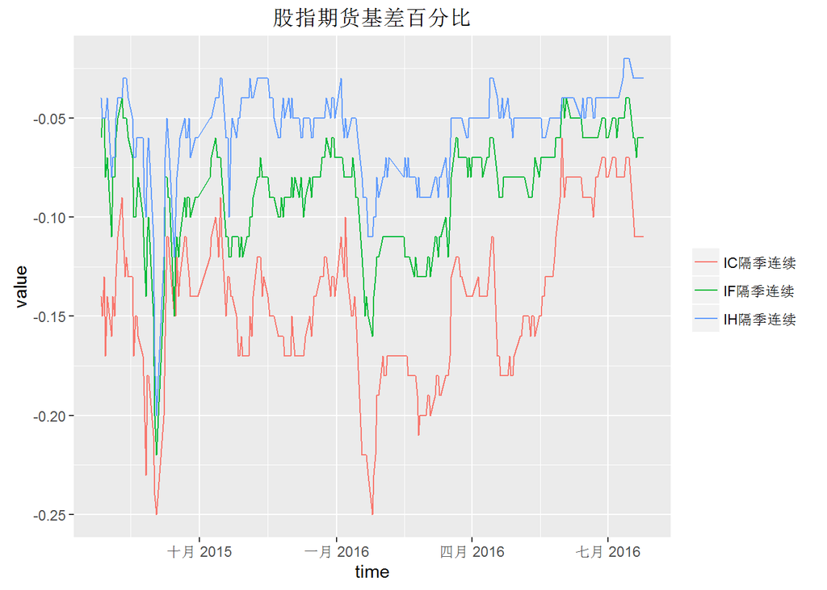

### (二)基差概况

三大股指期货连续合约基差概况如下表：

| 日期 | 合约简称 | 合约收盘价 | 基差 | 基差百分比 | 上周基差 | 上周基差百分比 |
| --- | --- | --- | --- | --- | --- | --- |
| 2016-07-25 | IH当月连续 | 2148.4 | -11.15 | -0.01 | -10.58 | 0.00 |
| 2016-07-25 | IH下月连续 | 2140.4 | -19.15 | -0.01 | -20.58 | -0.01 |
| 2016-07-25 | IH下季连续 | 2113.0 | -46.55 | -0.02 | -49.78 | -0.02 |
| 2016-07-25 | IH隔季连续 | 2096.2 | -63.35 | -0.03 | -64.78 | -0.03 |
| 2016-07-25 | IF当月连续 | 3198.0 | -32.89 | -0.01 | -37.82 | -0.01 |
| 2016-07-25 | IF下月连续 | 3168.4 | -62.49 | -0.02 | -69.22 | -0.02 |
| 2016-07-25 | IF下季连续 | 3094.0 | -136.89 | -0.04 | -146.42 | -0.04 |
| 2016-07-25 | IF隔季连续 | 3029.2 | -201.69 | -0.06 | -199.02 | -0.06 |
| 2016-07-25 | IC当月连续 | 6290.4 | -118.38 | -0.02 | -146.07 | -0.02 |
| 2016-07-25 | IC下月连续 | 6176.4 | -232.38 | -0.04 | -247.07 | -0.04 |
| 2016-07-25 | IC下季连续 | 5880.0 | -528.78 | -0.08 | -495.47 | -0.08 |
| 2016-07-25 | IC隔季连续 | 5681.0 | -727.78 | -0.11 | -672.07 | -0.10 |

## 三、套利

### (一)复牌股票套利

近两天复牌股票套利情况如下表：

[1] “无复牌股票套利”

### (二)定增基金跟踪

截止2016-07-26定增基金数据如下表，明细数据参见钱瀚的模板。

| 代码 | 名称 | 到期日期 | 最新净值 | 昨日收盘价 | 折溢价率 | 整体隐含折价率 | 大盘回撤0.1净值回撤 |
| --- | --- | --- | --- | --- | --- | --- | --- |
| 168101.OF | 九泰锐智 | 20200814 | 1.35 | 1.45 | 0.07 | 0.16 | -0.05 |
| 168102.OF | 九泰锐富 | 20210204 | 1.02 | 1.05 | 0.03 | 0.06 | -0.01 |
| 161222.OF | 国投瑞利 | 20160805 | 1.05 | 1.04 | -0.01 | 0.00 | -0.04 |
| 161225.OF | 国投瑞盈 | 20161119 | 1.03 | 1.05 | 0.02 | 0.06 | -0.08 |
| 501001.OF | 财通精选 | 20170101 | 1.11 | 1.06 | -0.04 | 0.02 | -0.09 |
| 501015.OF | 财通升级 | 20170908 | 1.02 | 1.01 | -0.01 | 0.10 | -0.02 |
| 160518.OF | 博时睿远 | 20171016 | 1.01 | 1.00 | 0.00 | 0.04 | -0.01 |

定增基金近期的净值走势如下图：

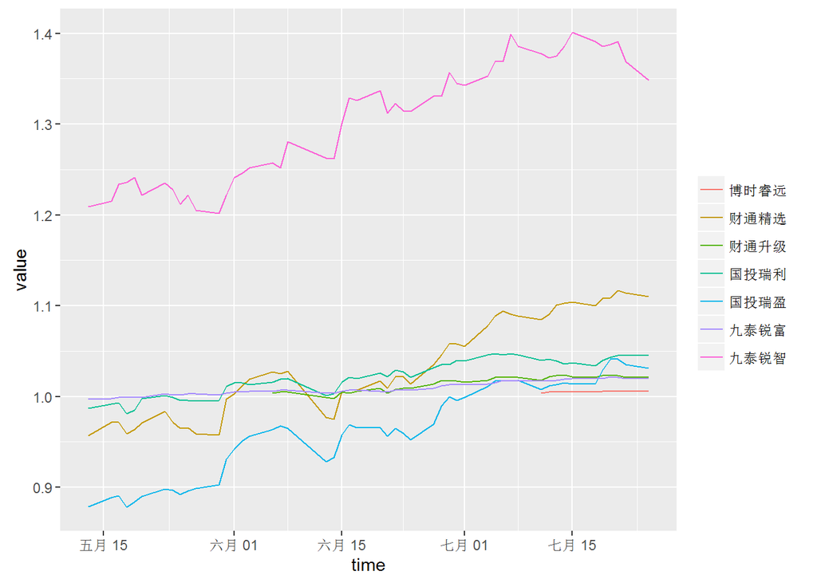

定增基金近期的折溢价走势如下图：

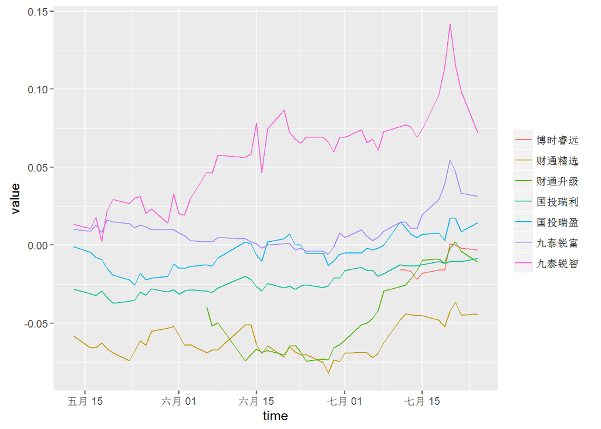

## 四、择时

### (一)大盘均线强弱指数

大盘均线强弱指数在一定程度上可以视为一个反转指标，当大盘均线得分接近8分时，预示市场接近顶部，当大盘均线得分接近0分时，预示市场接近底部。  
大盘均线强弱指数近一年来走势如下图：

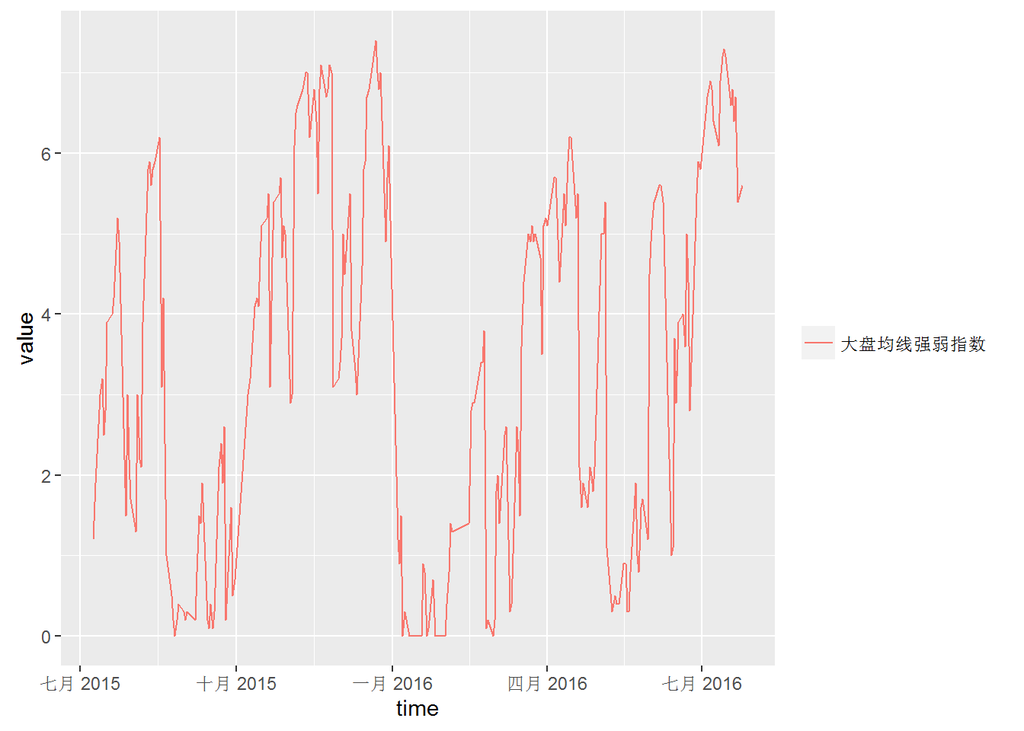

申万一级行业的最新得分及上周得分见下表：

| 日期 | 指数代码 | 指数名称 | 最新值 | 上周值 |
| --- | --- | --- | --- | --- |
| 2016-07-25 | EI801080 | 申万电子 | 8 | 5 |
| 2016-07-25 | EI801140 | 申万轻工制造 | 8 | 8 |
| 2016-07-25 | EI801230 | 申万综合 | 8 | 8 |
| 2016-07-25 | EI801710 | 申万建筑材料 | 8 | 8 |
| 2016-07-25 | EI801770 | 申万通信 | 8 | 8 |
| 2016-07-25 | EI801150 | 申万医药生物 | 7 | 8 |
| 2016-07-25 | EI801200 | 申万商业贸易 | 7 | 7 |
| 2016-07-25 | EI801010 | 申万农林牧渔 | 6 | 8 |
| 2016-07-25 | EI801030 | 申万化工 | 6 | 8 |
| 2016-07-25 | EI801110 | 申万家用电器 | 6 | 8 |
| 2016-07-25 | EI801120 | 申万食品饮料 | 6 | 7 |
| 2016-07-25 | EI801730 | 申万电气设备 | 6 | 6 |
| 2016-07-25 | EI801750 | 申万计算机 | 6 | 7 |
| 2016-07-25 | EI801880 | 申万汽车 | 6 | 8 |
| 2016-07-25 | EI801020 | 申万采掘 | 5 | 7 |
| 2016-07-25 | EI801050 | 申万有色金属 | 5 | 7 |
| 2016-07-25 | EI801130 | 申万纺织服装 | 5 | 8 |
| 2016-07-25 | EI801180 | 申万房地产 | 5 | 5 |
| 2016-07-25 | EI801720 | 申万建筑装饰 | 5 | 6 |
| 2016-07-25 | EI801740 | 申万国防军工 | 5 | 5 |
| 2016-07-25 | EI801760 | 申万传媒 | 5 | 6 |
| 2016-07-25 | EI801160 | 申万公用事业 | 4 | 6 |
| 2016-07-25 | EI801780 | 申万银行 | 4 | 8 |
| 2016-07-25 | EI801790 | 申万非银金融 | 4 | 5 |
| 2016-07-25 | EI801890 | 申万机械设备 | 4 | 5 |
| 2016-07-25 | EI801040 | 申万钢铁 | 3 | 5 |
| 2016-07-25 | EI801170 | 申万交通运输 | 3 | 6 |
| 2016-07-25 | EI801210 | 申万休闲服务 | 3 | 3 |

### (二)LLT及均线择时

LLT本质上是一个改进的单均线择时指标，较原始的均线择时延迟更低。  
择时模型和指数本身的净值走势如下图：

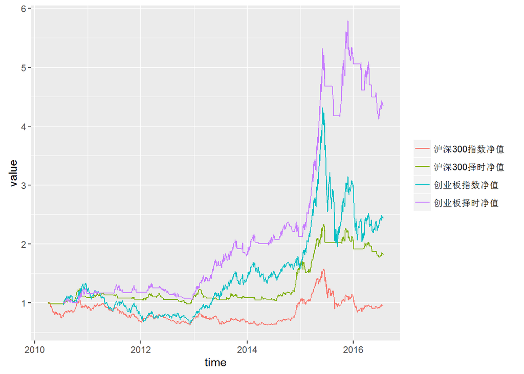

择时模型和指数的收益率统计如下表：

|  | 沪深300指 | 沪深300LLT | 创业板指 | 创业板MA |
| --- | --- | --- | --- | --- |
| 年化收益率 | -0.01 | 0.10 | 0.17 | 0.29 |
| 年化波动率 | 0.26 | 0.16 | 0.35 | 0.24 |
| 年化Sharpe值 | -0.03 | 0.63 | 0.48 | 1.20 |
| 最大回撤 | 0.47 | 0.24 | 0.55 | 0.29 |

择时模型最近10个交易日的信号如下表：

| 日期 | 沪深300收盘价 | 沪深300择时信号 | 创业板收盘价 | 创业板择时信号 |
| --- | --- | --- | --- | --- |
| 2016-07-12 | 3273.182 | hold | 2247.354 | hold |
| 2016-07-13 | 3282.868 | hold | 2285.369 | hold |
| 2016-07-14 | 3276.764 | hold | 2293.079 | hold |
| 2016-07-15 | 3276.278 | hold | 2263.784 | hold |
| 2016-07-18 | 3262.022 | hold | 2249.871 | hold |
| 2016-07-19 | 3248.234 | hold | 2273.719 | hold |
| 2016-07-20 | 3237.605 | hold | 2268.535 | hold |
| 2016-07-21 | 3252.523 | hold | 2265.128 | hold |
| 2016-07-22 | 3225.162 | hold | 2249.999 | hold |
| 2016-07-25 | 3230.885 | hold | 2245.885 | hold |

### (三)网格交易

在经历了三轮股灾，A股逐步回归正常，在过去的一段时间呈现一个震荡的格局，如果未来没有增量信息，很可能维持震荡。结合股指期货的贴水，前期研究了一下网格交易。网格交易的结果如下图：

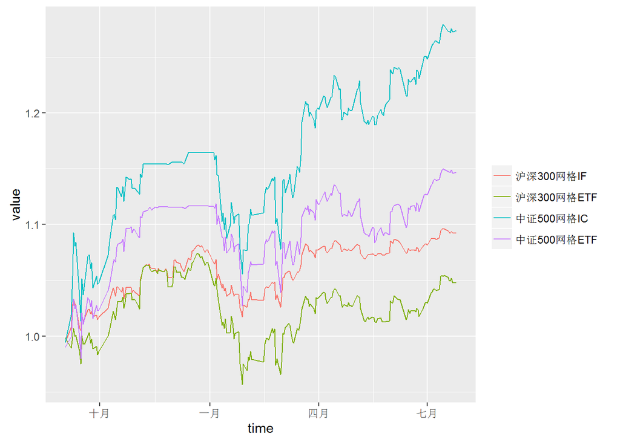

网格交易的收益统计如下表：

|  | 沪深300指数 | 沪深300网格IF | 沪深300网格ETF | 中证500指数 | 中证500网格IC | 中证500网格ETF |
| --- | --- | --- | --- | --- | --- | --- |
| 年化收益率 | -0.05 | 0.11 | 0.06 | 0.05 | 0.32 | 0.17 |
| 年化波动率 | 0.28 | 0.08 | 0.12 | 0.38 | 0.17 | 0.14 |
| 年化Sharpe值 | -0.16 | 1.35 | 0.46 | 0.12 | 1.86 | 1.24 |
| 最大回撤 | 0.26 | 0.06 | 0.11 | 0.33 | 0.09 | 0.08 |